# Week 8B: JAGS Intro

If you have not installed the following packages you need to install them: rjags, R2jags, runjags, MCMCpack

```r
library(R2jags)
library(lattice)
```

We will define a model using JAGS language. We will use the simple regression model from last class, where for $i = 1, ... , n$,
$$\begin{align*}
y_i & \sim \textrm{N} (\alpha + \beta(x_i -\overline{x}), \sigma^2) \\
\alpha & \sim \textrm{N}(0, 10^4) \\
\beta & \sim \textrm{N}(0, 10^4) \\
\sigma^{-2} & \sim \textrm{Ga}(0.1, 0.1)
\end{align*}$$

Now, we write this model in Jags.

```r
linear.model.JAGS = function(){
  for(i in 1:n){
    y[i] ~ dnorm(mu[i],tau2)
    mu[i]<- alpha + beta*(x[i]-x.bar)
  }
  x.bar <- mean(x)
  alpha ~ dnorm(0.0, 1.0E-4)
  beta ~ dnorm(0.0, 1.0E-4)
  sigma2 <- 1.0/tau2
  tau2 ~ dgamma(0.1,0.1)
}
```

Next, we need some data to fit the model to. We will simulate the following data.

```r
n = 100
x = rnorm(n,mean = 3.0, sd = 1)
y = 1.0 + 2.0*(x-3.0) + rnorm(n, 0, sd=0.5)
data.JAGS = list(y = y, x = x, n = n)
```

We also need to set the initial values of our Markov chain. The following contains two options. First, the parameter coefficients are set to 0 with unit precision. Second, the initial values are selected randomly.

```r
inits.JAGS = list(list(alpha=0.0,beta=0.0,tau2=1.0))
#inits.JAGS = function(){
  #return(list(alpha=rnorm(1),beta=rnorm(1),tau2=rgamma(0.1,0.1)))
#}
```

Now we set which parameters we’re going to simulate with our MCMC model:

```r
para.JAGS = c("alpha","beta","tau2","sigma2")
```

And, we fit the model:

```r
fit.JAGS = jags(data=data.JAGS,inits=inits.JAGS,
                parameters.to.save = para.JAGS,
                n.chains=1,
                n.iter=9000,
                n.burnin=1000,
                model.file=linear.model.JAGS)
```

This completes the code for the simple regression model. We can now make inferences and evaluate our model.

First, you can summarize the results. We will print the fit summary, and plot the parameter coefficient estimates as an rjags object and as an mcmc object.

```r
print(fit.JAGS)
```

```
Inference for Bugs model at "/var/folders/rh/l1j608wd1q7gxsz6pkpx67gm0000gn/T//RtmpvoNU1P/modeld57743538a50.txt", fit using jags,
 1 chains, each with 9000 iterations (first 1000 discarded), n.thin = 8
 n.sims = 1000 iterations saved
         mu.vect sd.vect    2.5%     25%     50%     75%   97.5%
alpha      1.337   0.046   1.240   1.308   1.339   1.368   1.422
beta       2.095   0.051   1.992   2.062   2.096   2.129   2.199
sigma2     0.230   0.034   0.173   0.207   0.227   0.252   0.307
tau2       4.434   0.643   3.258   3.973   4.399   4.838   5.775
deviance 134.872   2.469 132.022 133.057 134.217 135.997 141.284

DIC info (using the rule, pD = var(deviance)/2)
pD = 3.0 and DIC = 137.9
DIC is an estimate of expected predictive error (lower deviance is better).
```

We can also generate a simple plot as an rjags object, but as we will see below, there are more effective visualizations. This plot display the medians with an 80% interval bar.

```r
plot(fit.JAGS)
```

[output not shown]

Now we generate a traceplot to evaluate whether we are efficiently exploring the parameter space and sampling from the stationary distribution.

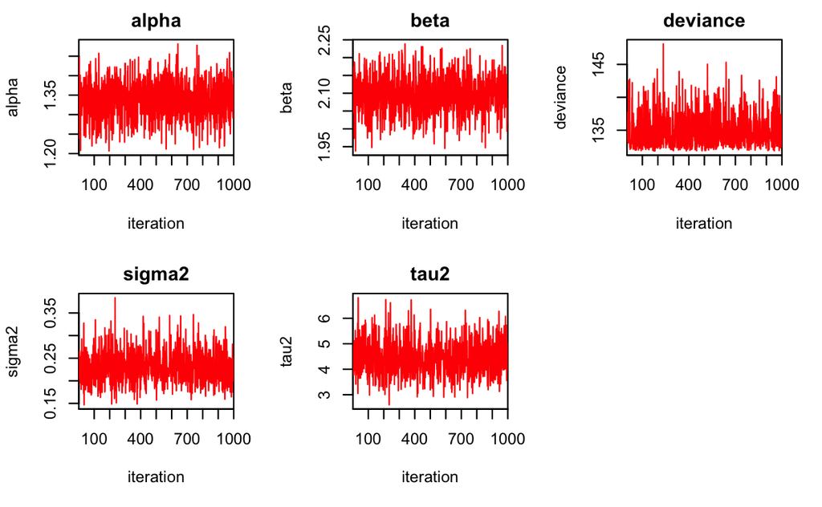

```r
traceplot(fit.JAGS,mfrow=c(2,3),ask=FALSE)
```

We can also plot as an MCMC object, which shows all the parameter densities along with their traceplots.

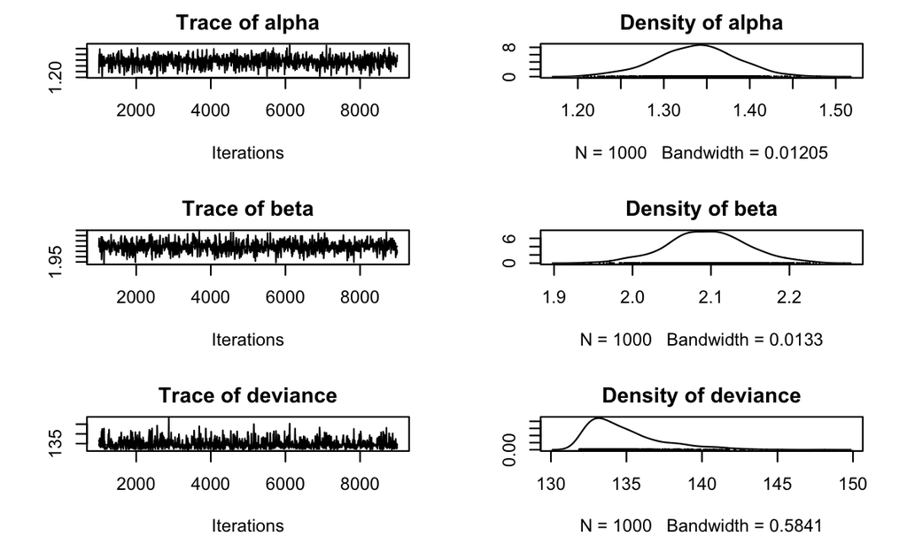

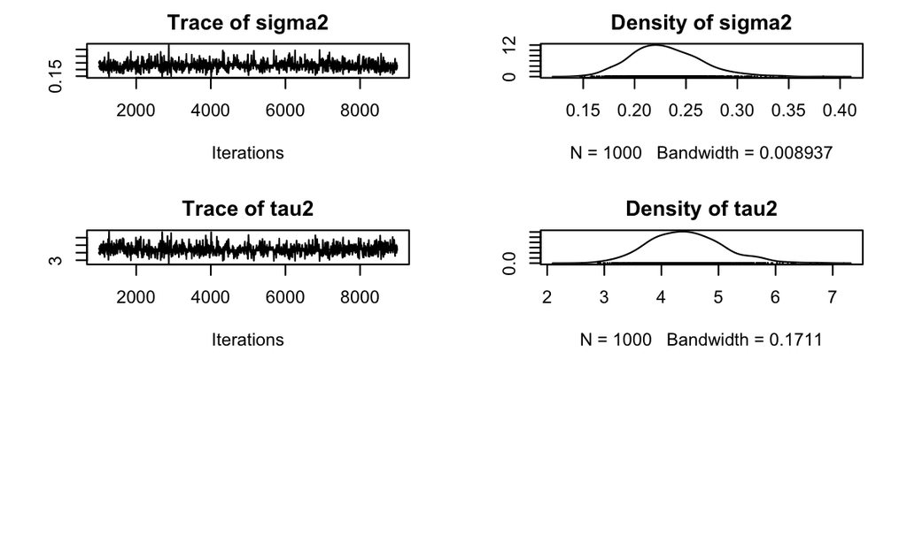

```r
fit.JAGS.mcmc = as.mcmc(fit.JAGS)
plot(fit.JAGS.mcmc,ask=FALSE)
```

We can also summarize as an MCMC object.

```r
summary(fit.JAGS.mcmc)
```

```
Iterations = 1001:8993
Thinning interval = 8
Number of chains = 1
Sample size per chain = 1000

1. Empirical mean and standard deviation for each variable,
   plus standard error of the mean:

             Mean      SD Naive SE Time-series SE
alpha      1.3374 0.04641 0.001468       0.001468
beta       2.0952 0.05095 0.001611       0.001611
deviance 134.8720 2.46911 0.078080       0.078080
sigma2     0.2303 0.03378 0.001068       0.001068
tau2       4.4338 0.64271 0.020324       0.020324

2. Quantiles for each variable:

             2.5%      25%      50%      75%   97.5%
alpha      1.2403   1.3075   1.3395   1.3681   1.422
beta       1.9922   2.0619   2.0960   2.1288   2.199
deviance 132.0222 133.0571 134.2170 135.9968 141.284
sigma2     0.1732   0.2067   0.2273   0.2517   0.307
tau2       3.2576   3.9733   4.3992   4.8379   5.775
```

And we can trace plot as an MCMC object.

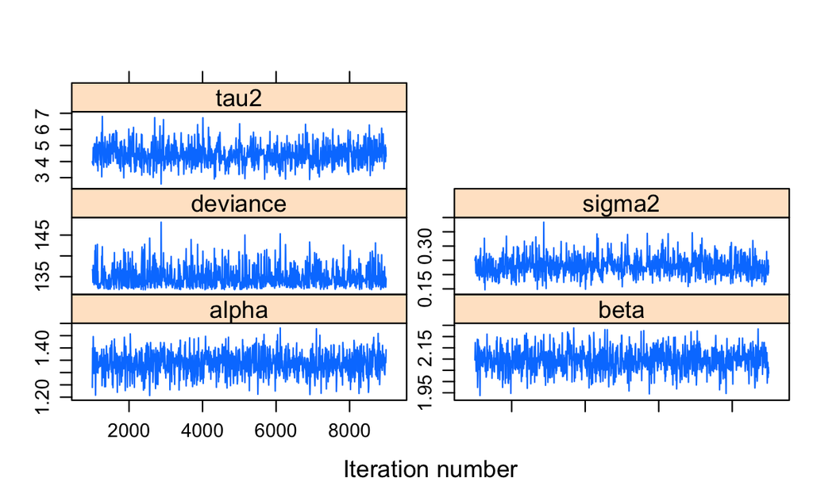

```r
xyplot(fit.JAGS.mcmc,layout=c(2,3))
```

We can also density plot as an MCMC object.

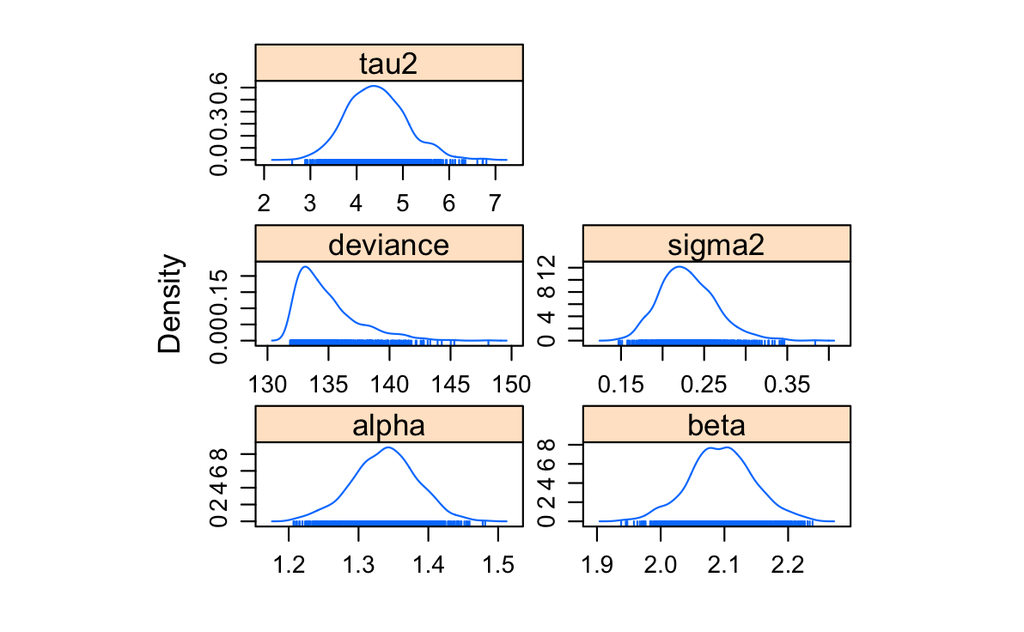

```r
densityplot(fit.JAGS.mcmc)
```

This completes our analysis of our first Bayesian regression model, together with basic diagnostics. We’ll talk later about model checking and more severe model assessments.